# Ithaphen - Analysis and generating paper plots

2023-05-08

# Demonstration of IthaPhen utility - Example 1

## Dataset

Dataset used in stepwise logistic regression

| outcome | N |
| --- | --- |
| deletional-HPFH | 61 |
| δβ-thalassaemia | 169 |

Missing observation per phenotypic parameter

| parameter | missing_obs |
| --- | --- |
| Hb | 35 |
| Hb A2 | 27 |
| Hb F | 4 |
| MCH | 47 |
| MCV | 47 |
| RBC | 118 |

## Stepwise logistic regression

Basic assumptions that must be met for *logistic* regression include: 1. independence of errors 2. linearity in the logit for continuous variables 3. absence of multicollinearity: Multicollinearity occurs when two or more independent variables have a high correlation with one another in a regression model, which makes it difficult to determine the individual effect of each independent variable on the dependent variable. 4. lack of strongly influential outliers.

In a regression model, consider including the interaction between 2 variables when:

1. They have large main effects: Variables that have a large influence on the outcome are more likely to have a statistically significant interaction with other factors that influence this outcome.
2. The effect of one independent variable changes for various subgroups of the other.
3. The interaction has been proven in previous studies.

ANOVA table for final model from stepwise regression

Step

Df

Deviance

Resid. Df

Resid. Dev

AIC

NA

NA

85

73.05197

75.05197

- `Hb F`

1

38.47601

84

34.57597

38.57597

- MCV

1

13.83851

83

20.73745

26.73745

## Final additive logistic regression model

Having identified significant predictors of δβ-thalassemia with stepwise regression analysis, we build an additive logistic regression model with those predictors using all the data with non missing pairwise observations.

Dataset used in final logistic regression model

| outcome | N |
| --- | --- |
| deletional-HPFH | 30 |
| δβ-thalassaemia | 149 |

fitting null model for pseudo-r2

pseudo-R2 measures for additive model

|  | . |
| --- | --- |
| llh | -41.0872071 |
| llhNull | -80.9181382 |
| G2 | 79.6618622 |
| McFadden | 0.4922374 |
| r2ML | 0.3592003 |
| r2CU | 0.6035973 |

### Checks for linearity and homoscedascity

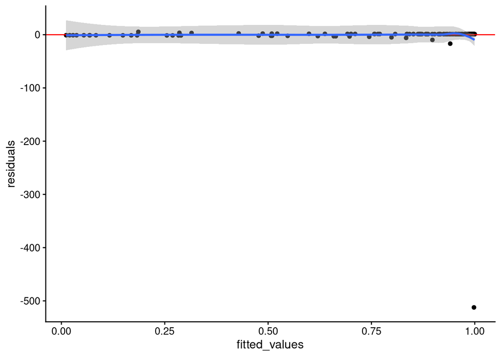

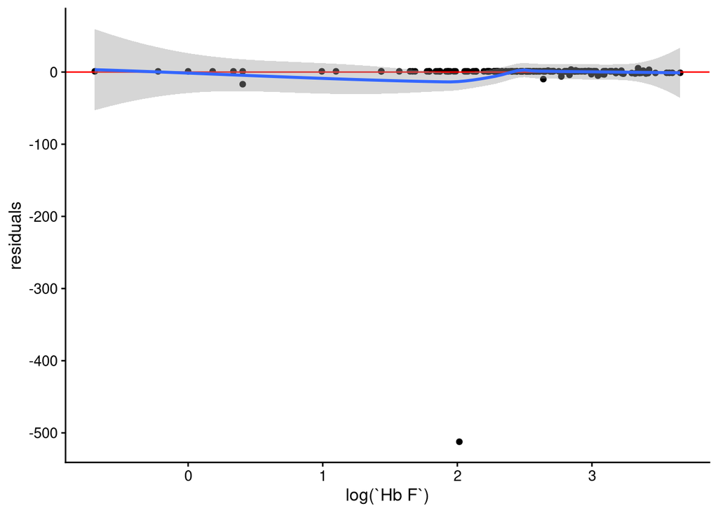

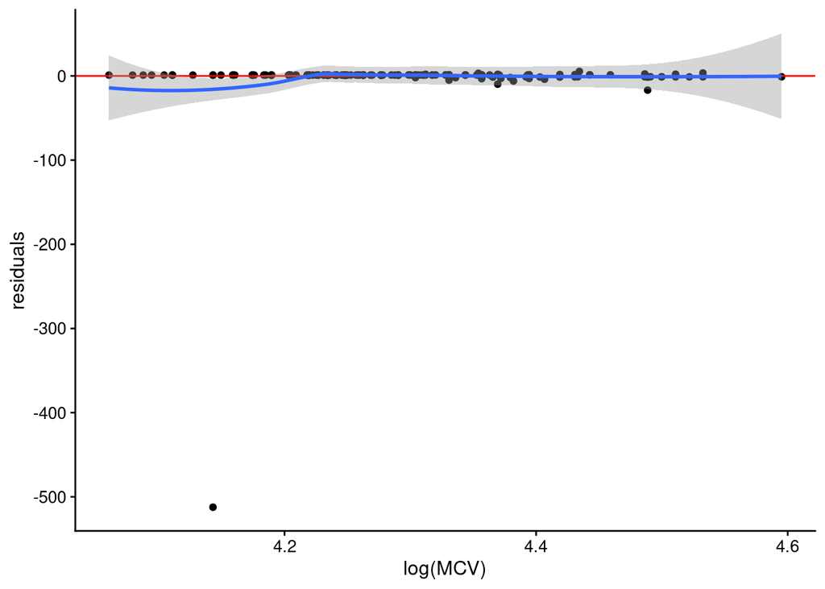

Variance inflation factor

|  | . |
| --- | --- |
| `Hb F` | 1.009591 |
| MCV | 1.009591 |

[output not shown]

[output cut: 4 more lines]

Odds ratio

| term | estimate | std.error | conf.level | conf.low | conf.high | statistic | df.error | p.value | p.stars | p.label | group | xpos | xmin | xmax |
| --- | --- | --- | --- | --- | --- | --- | --- | --- | --- | --- | --- | --- | --- | --- |
| Hb F | 0.8275827 | 0.0473489 | 0.95 | 0.7476526 | 0.9018303 | -3.996845 | Inf | 0.0000642 | *** | 0.83 *** | neg | 1 | 0.825 | 1.175 |
| MCV | 0.8375301 | 0.0471222 | 0.95 | 0.7571581 | 0.9129721 | -3.762519 | Inf | 0.0001682 | *** | 0.84 *** | neg | 2 | 1.825 | 2.175 |

# Demonstration of IthaPhen utility - Example 2

## LR computation

Likelihood ratios

| param | th_1 | th_2 | δβ-thalassemia | δβ-thalassemia_prob | deletional-HPFH | deletional-HPFH_prob | LR_formatted |
| --- | --- | --- | --- | --- | --- | --- | --- |
| Hb F | 0 | 10 | 48 | 0.322 | 2 | 0.067 | 4.832 (1.241, 18.809) |
| Hb F | 10 | 15 | 53 | 0.356 | 1 | 0.033 | 10.671 (1.535, 74.194) |
| Hb F | 15 | 20 | 34 | 0.228 | 3 | 0.100 | 2.282 (0.749, 6.948) |
| Hb F | 20 | 25 | 11 | 0.074 | 9 | 0.300 | 0.246 (0.112, 0.542) |
| Hb F | 25 | 100 | 3 | 0.020 | 15 | 0.500 | 0.04 (0.012, 0.131) |
| MCV | 0 | 70 | 68 | 0.456 | 1 | 0.033 | 13.691 (1.977, 94.8) |
| MCV | 70 | 75 | 45 | 0.302 | 1 | 0.033 | 9.06 (1.299, 63.204) |
| MCV | 75 | 80 | 23 | 0.154 | 9 | 0.300 | 0.515 (0.265, 0.999) |
| MCV | 80 | 100 | 13 | 0.087 | 19 | 0.633 | 0.138 (0.077, 0.248) |